# homework3

# 注意事項

存檔與填寫注意事項：

假設你叫王小明，學號41078392。

1. 存檔時，請用你的學號當延伸檔名。學號為41078392，則請存成homeworkX-41078392.Rmd, X為這次作業號碼。(記得使用：save with enconding, 然後選utf-8)
2. 本文檔開始的Frontmatter中，studentID（即key）其value目前為“你的學號”，以上面學號為例則必需改成“41078392”；而studentName（key）其value目前為“你的名字”，以上面名字為例則必需改成“王小明”

# 題目

請先執以下code chunk開啟RStudio底下的Python環境：

- 注意`use_python`的路徑及`use_condaenv`的沙盒環境必需改成你電腦的對應設定。

```python
import numpy as np
import pandas as pd
```

## 作答需知

- 每一題會有設好的ans chunk，請將你的程式寫在裡面，切勿自行加新的python chunk。
- 以下每個ans chunk的最後一行有#號mark起來是指定答案物件的名字，請將你運算答案存在該物件，並把最後一行的#號拿掉。

## 1 Probability distribution

Execute the following codes to retrieve the `joint_probability` object.

```python
import requests
import pickle
import numpy as np
import pandas as pd

q1data=requests.get("https://www.dropbox.com/s/f99mg0kfw52oked/hw3data.pickle?dl=1")
with open("hw3data.pickle","wb") as f:
    f.write(q1data.content)

with open("hw3data.pickle",'rb') as f:
    hw3data=pickle.load(f)

joint_probability=hw3data['joint_probability']
print(joint_probability)

if "q1ans" not in globals() or not isinstance(q1ans,(dict,)):
    q1ans = dict([])
```

[output not shown]

### 1.1 Setting index

`joint_probability` matrix is a joint probability of weather (rows) vs mood (columns). From row 0 to 2, the weather status is registered in `hw3data['weather index']`. From col 1 to 4, mood status is registered in `hw3data['mood index']`. Convert `joint_probability` to pd.dataFrame, and set weather status as its index and mood status as its column labels. Call this data frame as `df_jointP`.

```python
df_jointP = pd.DataFrame(joint_probability)
df_jointP.set_axis(hw3data['mood index'], axis=1)
df_jointP.set_axis(hw3data['weather index'], axis=0)
q1ans['df_jointP']=df_jointP
```

### 1.2 Sum across different axes

Compute marginal probability of weather (named it `marginP_weather`) and marginal probability of mood (named it `marginP_mood`)

```python
marginP_mood=np.sum(df_jointP, axis=0)
marginP_weather=np.sum(df_jointP, axis=1)
q1ans['marginP_weather']=marginP_weather; q1ans['marginP_mood']=marginP_mood
```

### 1.3 Divide method

Turn `joint_probability` into conditional probabilities of mood on weather (name it `P_mood_cond_weather`); and into conditional probabilities of weather on mood (name it `P_weather_cond_mood`). Hint: dataframe has .divide() method.

```python
for i in range(len(marginP_weather)):
  df_jointP.iloc[i].divide(marginP_weather[i])


for i in range(len(marginP_mood)):
  df_jointP.iloc[:,i].divide(marginP_mood[i])
# q1ans['P_mood_cond_weather']=P_mood_cond_weather; q1ans['P_weather_cond_mood']=P_weather_cond_mood
```

### 1.4 Select elements

What is the probability of a person being sad given that the weather is sunny? Name your result value as `p_ans14`.

```python
# q1ans['ans14']=p_ans14
```

### 1.5 Estimation

After you left home for office, you notice the weather is cloudy. Which mood your colleague is more likely to have? Name your result as `est_mood`.

```python
# q1ans['ans15']=est_mood
```

## 2. Numerical integration

A Riemann sum of a function over a partition
$$x_0 = a < x_1 < \cdots < x_{N-1} < x_N = b$$
is a sum of the form
$$\sum_{i=1}^N f(x_i^ * ) (x_i - x_{i-1}) \ \ , \ x_i^* \in [x_{i-1},x_i]$$
where each value $x_i^* \in [x_{i-1},x_i]$ in each subinterval is arbitrary.

The following questions guide you to understand its Python execution.

First, run the following codes to obtain a function `f()` representing:
$$f(x)=1/\log(x).$$

```python
import numpy as np
f = lambda x: 1/np.log(x)

if "q2ans" not in globals() or not isinstance(q1ans,(dict,)):
    q2ans = dict([])
```

### 2.1 A partition

Suppose the definite integral starts from `a=2` to `b=3`. Use `np.linspace()` to divide it into `N` **equal**-width intervals. Make sure that `len(<your array of partitions>)=N`. Save the partition array, name it `x_partition`, produced by `np.linspace()`.

```python
x_partition=np.linspace(2,3,100)
q2ans['x_partition']=x_partition
```

### 2.2 $x^*_i$ values

It says, “each value $x_i^* \in [x_{i-1},x_i]$ in each subinterval is arbitrary.”

We use a parameter $\alpha\in [0,1]$ to control our pick of $x_i^*$ such that
$$x_i^*=x_{i-1}+\alpha(x_i-x_{i-1})$$

When $\alpha=0$, $x^*_i=x_{i-1}$; when $\alpha=1$, $x^*_i=x_i$.

Define a function, called `x_star(x_partition, alpha=0.5)`:

```python
def x_star(x_partition, alpha=0.5):
    m=[]
    for i in range(len(x_partition)-1):
        m.append(x_partition[i]+alpha*(x_partition[i+1]-x_partition[i]))
    return(m)

q2ans['x_star']=x_star
```

### 2.3 Riemann sum

Compute the following sum:
$$\sum_{i=1}^N f(x_i^ * ) (x_i - x_{i-1}) \ \ , \ x_i^* \in [x_{i-1},x_i],$$

where $f=1/log(x)$, $a=2,b=3$, $N=100$, and $x^*_i$ is the midpoint of its corresponding interval. Save your result as `rsum`.

```python
logSum=0
for i in range(len(x_partition)-1):
  logSum+=f(x_star(x_partition))[i]*(x_partition[i+1]-x_partition[i])

# q2ans['ans23']=rsum
```

### 2.4 Riemann sum function

Complete the following function.

```python
def riemannsum(fun,interval,N=101,alpha=0.5):
    x_partition=np.linspace(interval[0],interval[1],N)
    logSum=0
    for i in range(len(x_partition)-1):
      logSum+=fun(x_star(x_partition,alpha))[i]*(x_partition[i+1]-x_partition[i])
    return(logSum)

# q2ans['riemannsum function']=riemannsum
```

If you did everythin correctly, run the following lines:

```python
import matplotlib.pyplot as plt
Nsequence = np.arange(100,1501)
Rsum = [riemannsum(f,[2,3],N_i) for N_i in Nsequence]

plt.plot(Nsequence, Rsum, 'b-', linewidth=2)
plt.show()
```

You should get a graph like

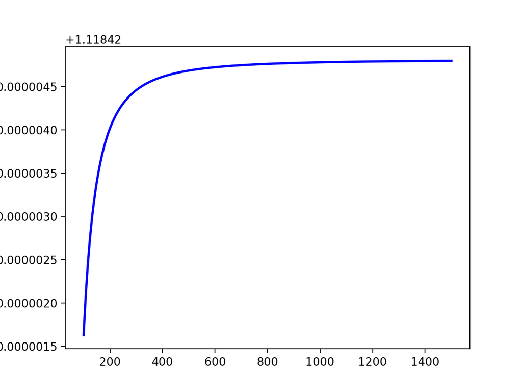